# Problem Set X

## Interpreting Run Value

### wOBA and Run Value

1. With your new `swtk19_summary` data frame, fit a linear regression using `lm()`, with y = wOBA and x = TR_p100p.
2. Add two new columns to `swtk19_summary`: the predicted values based on your fit, using `predict()`, and the corresponding residuals.
3. Graph a residual plot and double check your model is appropriate for the data.
4. Graph the relationship between total run value per 100 pitches and wOBA. Add your model regression line, and label the eight batters with the greatest residuals. *Hint: `geom_label_text()` can be used to text directly to the plot. `geom_label_repel()` draws a recentangle underneath the text, making it easier to read.*
5. What predictions for the 2020 season would you make about these eight batters, and why?

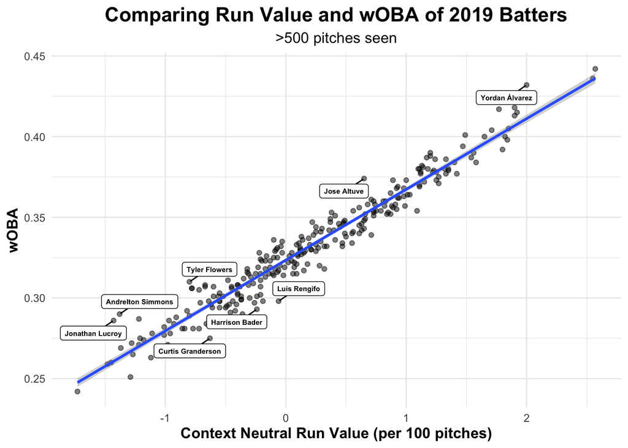

```r
### Solution ###
fit <- lm(wOBA ~ TR_p100p, data = swtk19_summary)

swtk19_summary <- swtk19_summary %>%
  mutate(pred_wOBA = predict(fit),
         resid = pred_wOBA - wOBA)

# residual plot
#ggplot(swtk19_summary, aes(x = TR_p100p, y = resid)) +
#   geom_point()

ggplot(swtk19_summary, aes(x = TR_p100p, y = wOBA)) +
  geom_point(alpha = 0.5) +
  geom_smooth(method = "lm", formula = y ~ x) +
  geom_label_repel(data = top_n(swtk19_summary, 8, abs(resid)),
             aes(label = batter_name), min.segment.length = 0, size = 2,
             fontface = "bold") +
  theme_minimal() +
  ggtitle(label = "Comparing Run Value and wOBA of 2019 Batters",
          subtitle = ">500 pitches seen") +
  xlab("Context Neutral Run Value (per 100 pitches)") +
  theme(plot.title = element_text(size = 16, face = "bold", hjust = 0.5),
        plot.subtitle = element_text(size = 12, hjust = 0.5),
        axis.title.x = element_text(size = 12, face="bold"),
        axis.title.y = element_text(size = 12, face="bold"))
```

### Run Value Generation

1. Graph the relationship between run value generated from swings and takes. Add guide lines using `geom_abline()` to identify total run value benchmarks: 30, 40, and 50. Using a nested `filter()`, label players with >30 total run value.

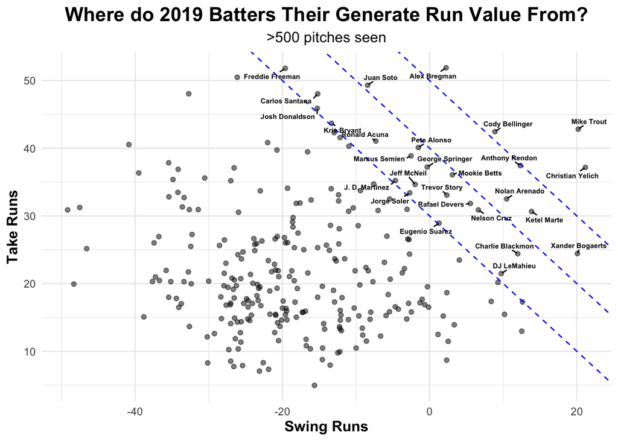

```r
### Solution ###
ggplot(swtk19_summary, aes(x = Swing_Runs, y = Take_Runs)) +
  geom_point(alpha = 0.5) +
  geom_abline(intercept = 50, slope = -1, linetype = "dashed", color = "blue") +
  geom_abline(intercept = 40, slope = -1, linetype = "dashed", color = "blue") +
  geom_abline(intercept = 30, slope = -1, linetype = "dashed", color = "blue") +
  geom_text_repel(data = filter(swtk19_summary, Total_Runs > 30),
                   aes(label = batter_name), min.segment.length = 0,
                   size = 2, fontface = "bold") +
  theme_minimal() +
  ggtitle(label = "Where do 2019 Batters Their Generate Run Value From?",
          subtitle = ">500 pitches seen") +
  xlab("Swing Runs") +
  ylab("Take Runs") +
  theme(plot.title = element_text(size = 16, face = "bold", hjust = 0.5),
        plot.subtitle = element_text(size = 12, hjust = 0.5),
        axis.title.x = element_text(size = 12, face="bold"),
        axis.title.y = element_text(size = 12, face="bold"))
```